# dnn_assignment

# Effect of epochs

```python
# Set epochs to 10. Keep the rest same as Question 1. Five lines of code
model1.epochs = 10
model1.learning_rate = 0.16
model1.layers = [1, 22, 12, 12, 1]
model1.momentum = 0
model1.p_train = 0.7
```

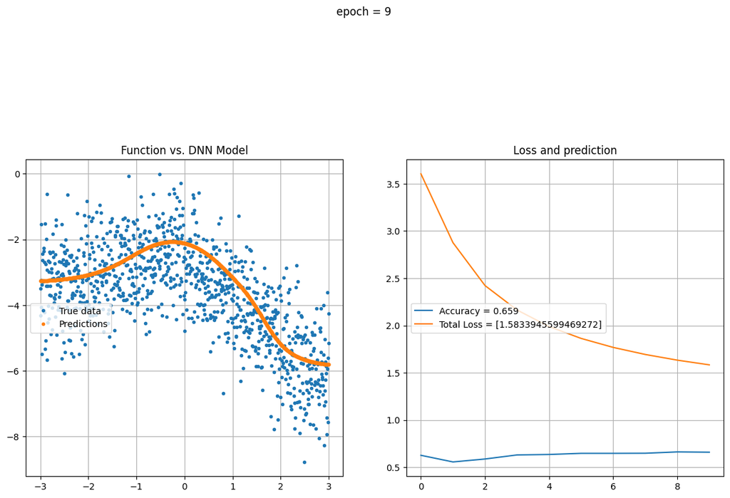

```python
# Set parameters and train the model. Two lines of code
model1.set_parameters()
model1.train(save_at = 100)
```

```
Validation error for the trained model = 1.1729813202293826
Validation error against real data: 0.10776153741321881
```

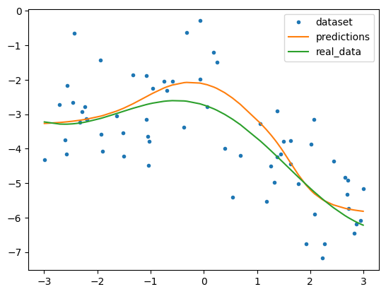

```python
# Validate against real data. One line of code
model1.validation_real_data()
```

```python
# Set epochs to 2000. Keep the rest same as Question 1. Five lines of code
model1.epochs = 2000
model1.learning_rate = 0.16
model1.layers = [1, 22, 12, 12, 1]
model1.momentum = 0
model1.p_train = 0.7
```

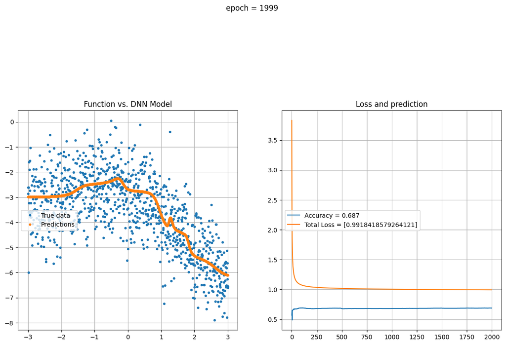

```python
# Set parameters and train the model. Two lines of code
model1.set_parameters()
model1.train(save_at = 100)
```

```
Validation error for the trained model = 0.8755565746281526
Validation error against real data: 0.04619388555124915
```

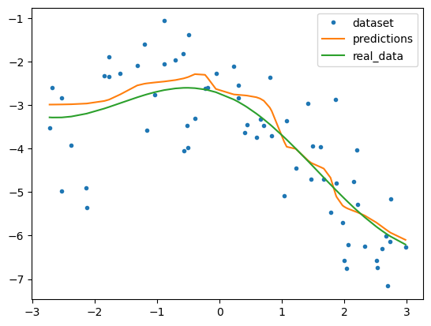

```python
# Validate against real data. One line of code
model1.validation_real_data()
```

# Effect of learning rate

```python
# Set learning rate to 0.1. Keep the rest same as Question 1. Five lines of code
model1.epochs = 2
model1.learning_rate = 0.1
model1.layers = [1, 22, 12, 12, 1]
model1.momentum = 0
model1.p_train = 0.7
```

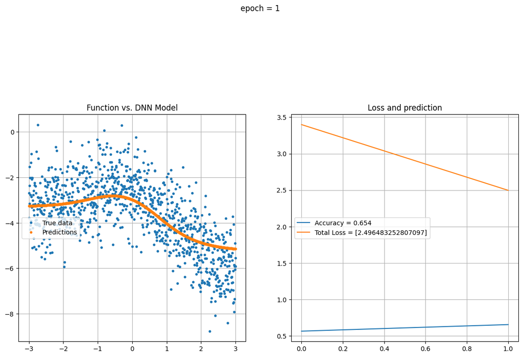

```python
# Set parameters and train the model. Two lines of code
model1.set_parameters()
model1.train(save_at = 100)
```

```
Validation error for the trained model = 0.9199272489795476
Validation error against real data: 0.17271902648748583
```

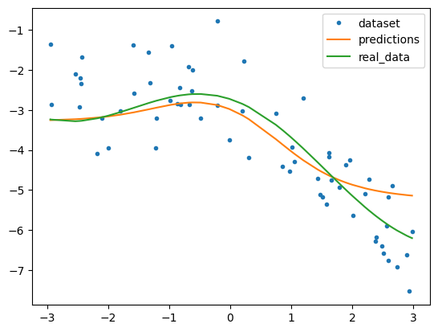

```python
# Validate against real data. One line of code
model1.validation_real_data()
```

```python
# Set learning rate to 0.001. Keep the rest same as Question 1. Five lines of code
model1.epochs = 2
model1.learning_rate = 0.001
model1.layers = [1, 22, 12, 12, 1]
model1.momentum = 0
model1.p_train = 0.7
```

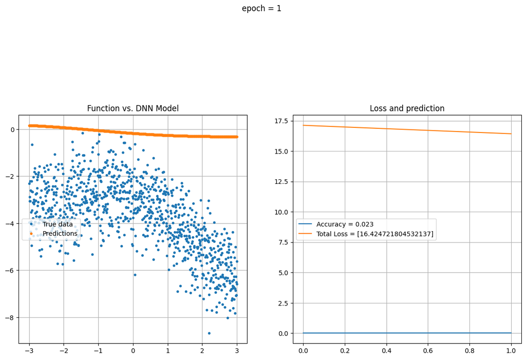

```python
# Set parameters and train the model. Two lines of code
model1.set_parameters()
model1.train(save_at = 100)
```

```
Validation error for the trained model = 14.332868189094427
Validation error against real data: 14.714078119107455
```

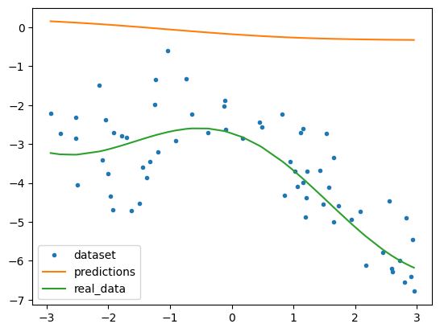

```python
# Validate against real data. One line of code
model1.validation_real_data()
```

### Fill in the following table. Replace "x" with numerics. Specify Underfit or Overfit in comparison to against Original Solution unless until specified otherwise

- Note: Double-click to edit

[output not shown]

## Please add further comments below

a.) While reducing the number of layers can help mitigate overfitting in some cases, it's essential to strike a balance between model complexity and simplicity. It's crucial to experiment and find the optimal number of layers for the given problem

c.) Increasing the training data percentage is generally a good practice, especially if the dataset is small. However, it's essential to ensure a balanced distribution between training, validation, and test sets.

d.) Finding the right number of epochs is crucial. This is often done using techniques like early stopping or monitoring the validation error

e.) Adjusting the learning rate is crucial for optimizing the training process. Too high a learning rate might cause the model to diverge or oscillate, while too low a learning rate might result in slow convergence. It's often necessary to tune the learning rate based on the specific problem and model architecture.